# Penguin lab - flipper lengths, ANOVA

An Bui

07 November 2018

#### 1. Set up.

```r
library(tidyverse)
library(car)
library(onewaytests)

penguins <- read_csv("penguins.csv")
```

#### 2. Introductory data wrangling.

**Question: is there a significant difference in mean flipper lengths for female Chinstrap, Gentoo, and Adelie penguins near Palmer Archepelago?**  
One factor: species (penguins)  
Levels: 3 (Chinstrap, Gentoo, Adelie)  
Continuous random variable: flipper length  
This means you can use a **one-way ANOVA.**

Assume:  
- independent observations  
- equal variance (Levene’s test)  
- normality (histograms/qqplots)

Figure out of your data fulfill these assumptions. First, count up your data.

```r
# with dataset penguins, create a table of counts
counts <- with(penguins, table(Species, Sex))
```

Seems like there are >30 samples, so you can use CLT to justify an ANOVA.

```r
# create a new data frame from penguins
penguins2 <- penguins %>%
  # add a new column using mutate
  mutate(
    # call that column common_name
    common_name =
      # use case_when for common names of penguins to match with the other column of both scientific and common
      case_when(
        Species == "Chinstrap penguin (Pygoscelis antarctica)" ~ "Chinstrap",
        Species == "Gentoo penguin (Pygoscelis papua)" ~ "Gentoo",
        Species == "Adelie Penguin (Pygoscelis adeliae)" ~ "Adelie"
      )
  ) %>%
  # retain all columns except Species
  select(-Species) %>%
  # filter for female penguins
  filter(Sex == "FEMALE")
```

Now, make some exploratory graphs.

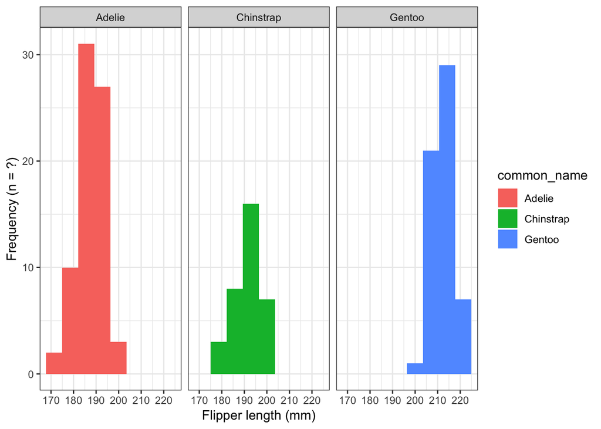

```r
penguins_hist <- ggplot(penguins2, aes(x = flipper_length)) +
  geom_histogram(aes(fill = common_name),
                 bins = 8) +
  facet_wrap (~ common_name) +
  theme_bw() +
  labs(x = "Flipper length (mm)", y = "Frequency (n = ?)")

penguins_hist
```

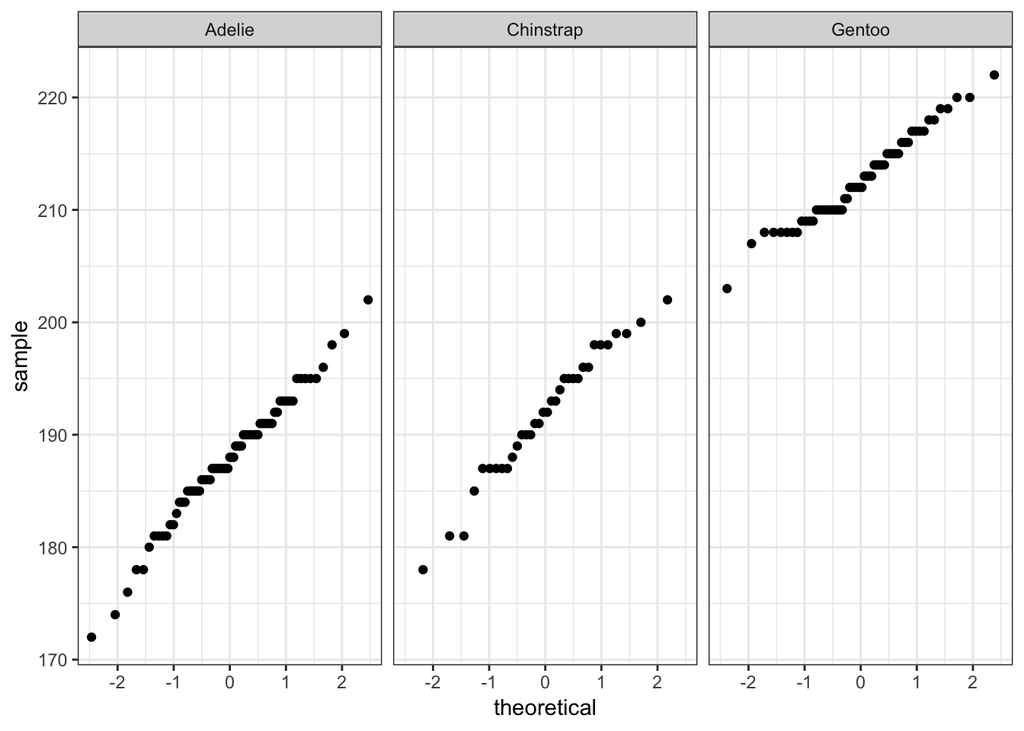

```r
penguins_qq <- ggplot(penguins2, aes(sample = flipper_length)) +
  geom_qq() +
  facet_wrap(~ common_name) +
  theme_bw()

penguins_qq
```

Based on qqplots and histograms, observations for each group seems normally distributed. Also, n > 30 so means will be normally distributed by CLT.

Then, test for equal variances. If the largest sample variance is < 4x greater than the samllest sample variance, then these are “close enough” to consider variances equal.

```r
# new data frame from penguins
variances <- penguins2 %>%
  # group by species
  group_by(common_name) %>%
  summarize(
    variance = var(flipper_length)
  )
```

Largest variance (33) is not more than 4x greater than the smallest variance (15).

Then, use a Levene’s test (in `car` package).  
**H<sub>0</sub>:** No difference in variances.  
**H<sub>A</sub>:** Variances are *not* equal.

```r
# do a Levene's test
levene_penguin <- leveneTest(flipper_length ~ common_name, data = penguins2)
levene_penguin
```

```
## Levene's Test for Homogeneity of Variance (center = median)
##        Df F value  Pr(>F)
## group   2  2.9012 0.05782 .
##       162
## ---
## Signif. codes:  0 '***' 0.001 '**' 0.01 '*' 0.05 '.' 0.1 ' ' 1
```

There is no significant difference in variances across species. Therefore, you can do a one-way ANOVA.

#### 3. ANOVA and post-hoc testing

**H<sub>0</sub>:** All means are the same. **H<sub>A</sub>:** At least two means are different.

```r
# compare means of random variable flipper_length based on common_name
penguin_aov <- aov(flipper_length ~ common_name, data = penguins2)

# use summary() to get outcome of aov()
summary(penguin_aov)
```

```
##              Df Sum Sq Mean Sq F value Pr(>F)
## common_name   2  21416   10708   411.8 <2e-16 ***
## Residuals   162   4213      26
## ---
## Signif. codes:  0 '***' 0.001 '**' 0.01 '*' 0.05 '.' 0.1 ' ' 1
```

So, at least two means are different. But which ones are actually different? Use a post-hoc Tukey’s HSD.

```r
# do a Tukey's HSD on your ANOVA
penguin_ph <- TukeyHSD(penguin_aov)
penguin_ph
```

```
##   Tukey multiple comparisons of means
##     95% family-wise confidence level
##
## Fit: aov(formula = flipper_length ~ common_name, data = penguins2)
##
## $common_name
##                       diff       lwr       upr     p adj
## Chinstrap-Adelie  3.940774  1.436275  6.445272 0.0007922
## Gentoo-Adelie    24.912376 22.790647 27.034105 0.0000000
## Gentoo-Chinstrap 20.971602 18.366227 23.576977 0.0000000
```